# Week 7

Kerri Luttrell

2/24/2021

# PART FOUR: Homework

Using the model from Part One (two competitors, one resource): 1. Alter the parameters such that a_N > a_M, and l_N > l_M. List your parameters here. = /2 points total

```r
r <- .5     # Intrinsic growth rate of the resource
K <- 100    # Carrying capacity of the resource

a_M <- 0.2 # Affinity or attack rate of M for/on the resource R
a_N <- a_M*1.5

e <- 0.05   # Conversion efficiency of R into N or M
l_M <- 0.01 # Mortality rate of N
l_N <- l_M*1.25
```

2. Calculate R* for both species N and species M. = /2 points total

```r
Rstar_N <- l_N/e/a_N
Rstar_N
```

```
## [1] 0.8333333
```

```r
Rstar_M <- l_M/e/a_M
Rstar_M
```

```
## [1] 1
```

3. Based on your calculation, predict which species should “win” competition. = /1 point total

```r
#Species N should when because it has a lower Rstar value and is thus more competitively dominant than species M.
```

4. Run a simulation and make a timeseries plot to confirm your prediction. /2 points for two sets of axes /3 points for each line (R, N, M) /1 point for legend /2 points for code = /8 points total

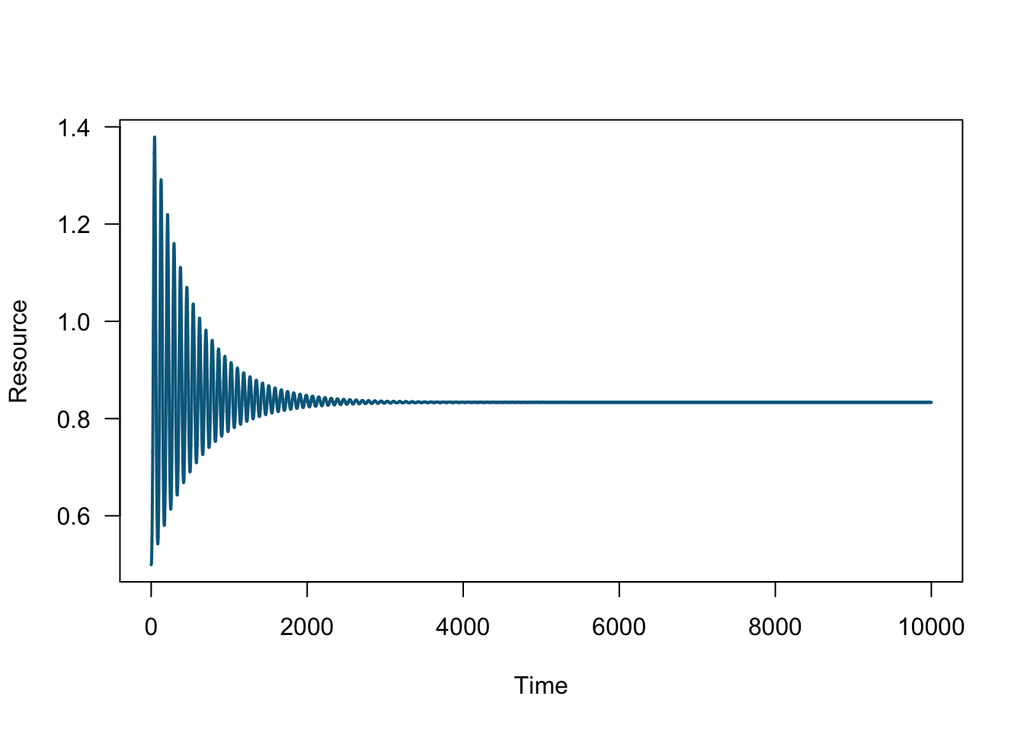

```r
# choosing timesteps to iterate over
tset1 <- seq(from=0, to=10000, length.out = 100000)

# filling in our initial conditions
R.simu1 <- NaN*tset1; R.simu1[1] <- 0.5
N.simu1 <- NaN*tset1; N.simu1[1] <- 1
M.simu1 <- NaN*tset1; M.simu1[1] <- 1

# for each element i from the second to the last in tset1
for(i in 2:length(tset1)){
  # calculate the change in time
    dt <- tset1[i]-tset1[i-1]

    # store dummy variables
    R <- R.simu1[i-1]
    N <- N.simu1[i-1]
    M <- M.simu1[i-1]

    # calculate change in population size at this timestep
    dR <- ( r*R*(1-R/K) - a_N*N*R - a_M*M*R )*dt
    dN <- ( e*a_N*N*R - l_N*N )*dt
    dM <- ( e*a_M*M*R - l_M*M )*dt

    # calculate total population size and store in holding vector
    R.simu1[i] <- R + dR
    N.simu1[i] <- N + dN
    M.simu1[i] <- M + dM
}

Rcol <- 'deepskyblue4'
Ncol <- 'coral'
Mcol <- 'seagreen'

# plot R as a function of time
plot(tset1,R.simu1,type='l',las=1,lwd=2,ylab='Resource',xlab='Time',col=Rcol)
```

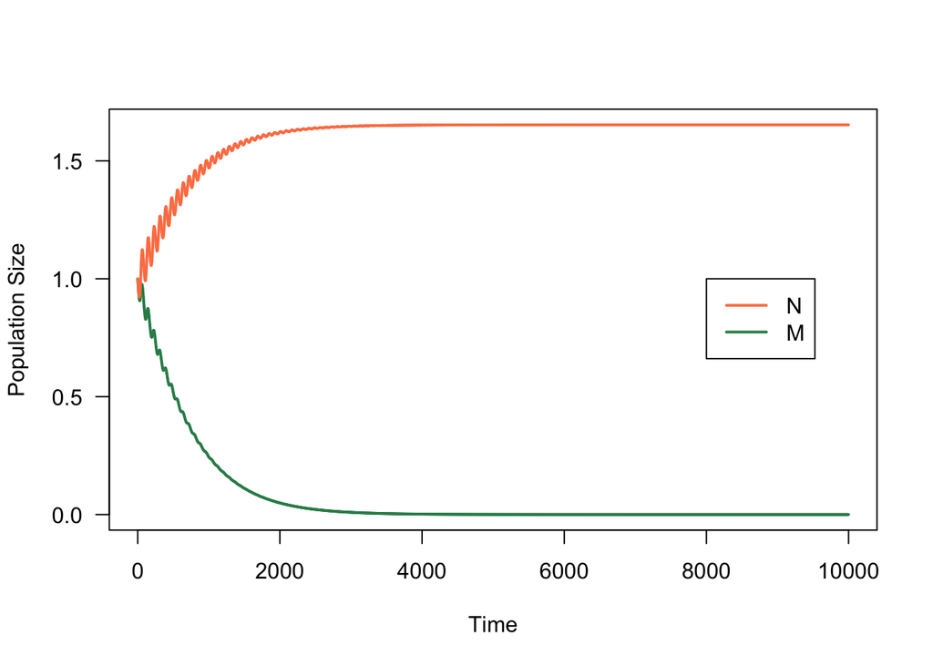

```r
# plot species N and M as function time
plot(tset1,M.simu1,type='l',las=1,lwd=2,ylab='Population Size',xlab='Time',col=Mcol,ylim=c(0,max(c(max(M.simu1,N.simu1)))))
lines(tset1,N.simu1,lwd=2,col=Ncol)
legend(x=8000,y=1,legend=c('N','M'),lwd=2,col=c(Ncol,Mcol))
```

```r
tail(R.simu1)
```

```
## [1] 0.8333333 0.8333333 0.8333333 0.8333333 0.8333333 0.8333333
```

```r
R.simu1[length(R.simu1)]
```

```
## [1] 0.8333333
```

```r
Rstar_M
```

```
## [1] 1
```

5. Try some different initial conditions. Do you believe that the system has only one stable equilibrium? /2 points for a simulation with different initial conditions /2 points for either a plot or tail values to find stable equilibria /1 point for answer /2 points for code = /7 points total

```r
r <- .5     # Intrinsic growth rate of the resource
K <- 100    # Carrying capacity of the resource

a_M <- 0.2 # Affinity or attack rate of M for/on the resource R
a_N <- a_M*1.5

e <- 0.05   # Conversion efficiency of R into N or M
l_M <- 0.01 # Mortality rate of N
l_N <- l_M*1.25
```

```r
Rstar_N <- l_N/e/a_N
Rstar_N
```

```
## [1] 0.8333333
```

```r
Rstar_M <- l_M/e/a_M
Rstar_M
```

```
## [1] 1
```

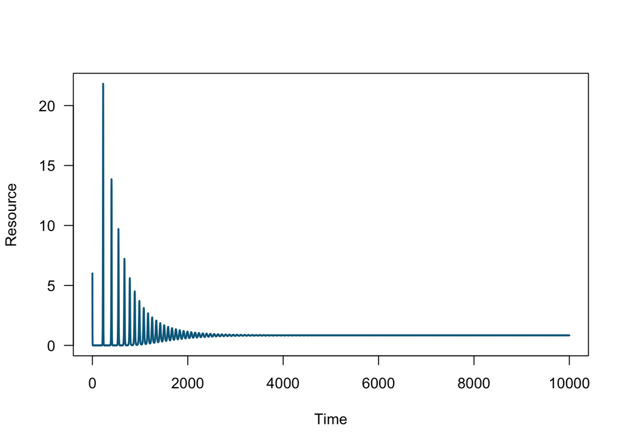

```r
# choosing timesteps to iterate over
tset1 <- seq(from=0, to=10000, length.out = 100000)

# filling in our initial conditions
R.simu2 <- NaN*tset1; R.simu2[1] <- 6
N.simu2 <- NaN*tset1; N.simu2[1] <-2
M.simu2 <- NaN*tset1; M.simu2[1] <- 3

# for each element i from the second to the last in tset1
for(i in 2:length(tset1)){
  # calculate the change in time
    dt <- tset1[i]-tset1[i-1]

    # store dummy variables
    R <- R.simu2[i-1]
    N <- N.simu2[i-1]
    M <- M.simu2[i-1]

    # calculate change in population size at this timestep
    dR <- ( r*R*(1-R/K) - a_N*N*R - a_M*M*R )*dt
    dN <- ( e*a_N*N*R - l_N*N )*dt
    dM <- ( e*a_M*M*R - l_M*M )*dt

    # calculate total population size and store in holding vector
    R.simu2[i] <- R + dR
    N.simu2[i] <- N + dN
    M.simu2[i] <- M + dM
}

Rcol <- 'deepskyblue4'
Ncol <- 'coral'
Mcol <- 'seagreen'

# plot R as a function of time
plot(tset1,R.simu2,type='l',las=1,lwd=2,ylab='Resource',xlab='Time',col=Rcol)
```

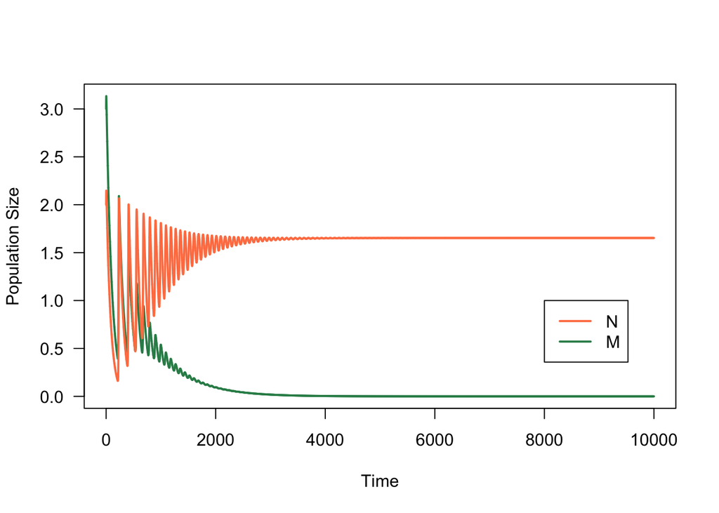

```r
# plot species N and M as function time
plot(tset1,M.simu2,type='l',las=1,lwd=2,ylab='Population Size', xlab='Time',col=Mcol, ylim=c(0,max(c(max(M.simu2,N.simu2)))))
lines(tset1,N.simu2,lwd=2,col=Ncol)
legend(x=8000,y=1,legend=c('N','M'),lwd=2,col=c(Ncol,Mcol))
```

```r
tail(R.simu2)
```

```
## [1] 0.8333333 0.8333333 0.8333333 0.8333333 0.8333333 0.8333333
```

```r
Rstar_M
```

```
## [1] 1
```

```r
  tail(N.simu2)
```

```
## [1] 1.652778 1.652778 1.652778 1.652778 1.652778 1.652778
```

```r
  tail(M.simu2)
```

```
## [1] 1.547713e-07 1.547455e-07 1.547197e-07 1.546940e-07 1.546682e-07
## [6] 1.546424e-07
```

I believe there is only one stable equilibrium in this system. Regardless of how I change the initial conditions, for this set of parameters the end result always shows N outcompeting M and R settling out at a value of 0.833.